# Progetto Statistica descrittiva

Per quanto riguarda le città ha senso comunque creare un grafico normalizzato in quanto le città potrebbero avere un numero di abitanti significativamente diverso. Questo significa avere più o meno possibilità di acquisto di immobili.

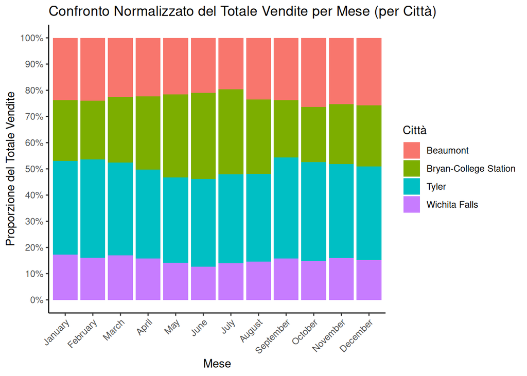

```r
ggplot(data = vendite_totali_mese_città) +
  geom_bar(aes(x = month, y = tot_vendite, fill = city),
           position = "fill",
           stat = "identity") +
  labs(title = "Confronto Normalizzato del Totale Vendite per Mese (per Città)",
       x = "Mese",
       y = "Proporzione del Totale Vendite",
       fill = "Città") +
  scale_y_continuous(breaks = seq(0, 1, 0.1), labels = scales::percent) +
  theme_classic()+
  theme(axis.text.x = element_text(angle = 45, hjust = 1))
```

Questo grafico evidenzia come la quota di mercato in termini di numero di vendite cambi leggermente tra le città nel corso dei mesi, indipendentemente dal volume assoluto delle vendite. Comunque in generale non si hanno troppe variazioni informative tra il grafico precedente e questo normalizzato.

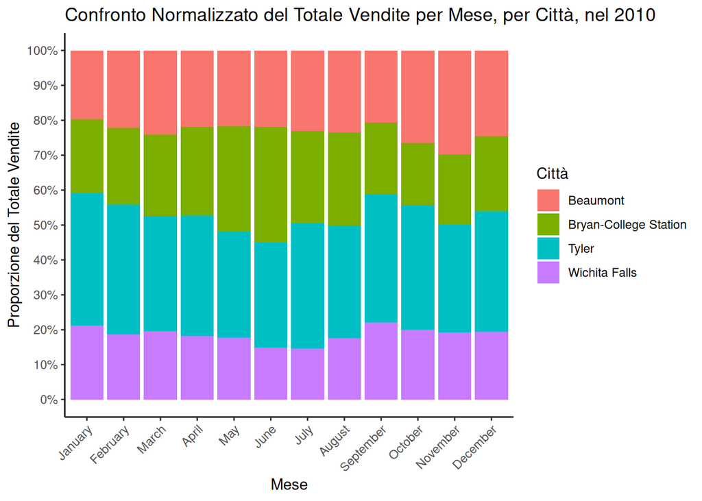

```r
#Adesso scegliendo un anno per esempio il 2010
vendite_totali_mese_città_2010 <- dati %>%
  group_by(month, city) %>%
  filter(year == 2010) %>%
  summarize(tot_vendite = sum(sales, na.rm = TRUE)) %>%
  ungroup()

ggplot(data = vendite_totali_mese_città_2010) +
  geom_bar(aes(x = month, y = tot_vendite, fill = city),
           position = "fill",
           stat = "identity") +
  labs(title = "Confronto Normalizzato del Totale Vendite per Mese, per Città, nel 2010",
       x = "Mese",
       y = "Proporzione del Totale Vendite",
       fill = "Città") +
  scale_y_continuous(breaks = seq(0, 1, 0.1), labels = scales::percent) +
  theme_classic()+
  theme(axis.text.x = element_text(angle = 45, hjust = 1))
```

Simile al grafico precedente, questo mostra la proporzione del totale delle vendite mensili per ciascuna città, ma specificamente per l’anno 2010. Le tendenze generali osservate nel grafico precedente sembrano essere presenti anche nel 2010, con Wichita Falls che mantiene una quota relativamente stabile e le altre città che mostrano fluttuazioni.

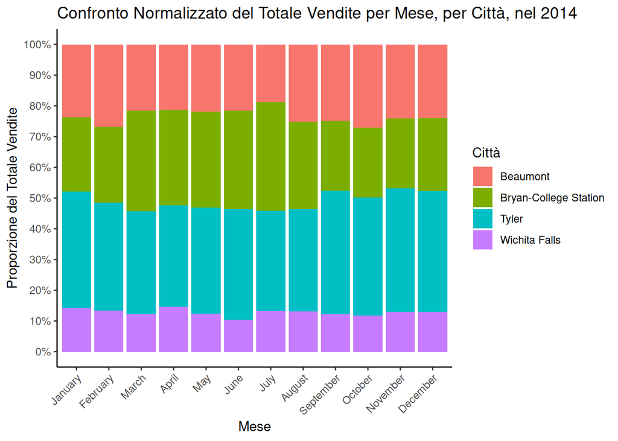

```r
#vediamo per il 2014
vendite_totali_mese_città_2014 <- dati %>%
  group_by(month, city) %>%
  filter(year == 2014) %>%
  summarize(tot_vendite = sum(sales, na.rm = TRUE)) %>%
  ungroup()

ggplot(data = vendite_totali_mese_città_2014) +
  geom_bar(aes(x = month, y = tot_vendite, fill = city),
           position = "fill",
           stat = "identity") +
  labs(title = "Confronto Normalizzato del Totale Vendite per Mese, per Città, nel 2014",
       x = "Mese",
       y = "Proporzione del Totale Vendite",
       fill = "Città") +
  scale_y_continuous(breaks = seq(0, 1, 0.1), labels = scales::percent) +
  theme_classic()+
  theme(axis.text.x = element_text(angle = 45, hjust = 1))
```

Anche questo grafico mostra la proporzione del totale delle vendite mensili per ciascuna città, ma focalizzandosi sull’anno 2014. Rispetto al 2010, si possono notare alcune differenze nelle proporzioni, suggerendo possibili cambiamenti nelle quote di mercato tra le città nel corso del tempo. Ad esempio, la proporzione di una specifica città potrebbe essere leggermente aumentata o diminuita nel 2014 rispetto al 2010.

In generale, questi ultimi tre grafici normalizzati permettono di analizzare come la “torta” delle vendite totali mensili si divide tra le diverse città, indipendentemente dalle variazioni nel volume assoluto delle vendite nel tempo.

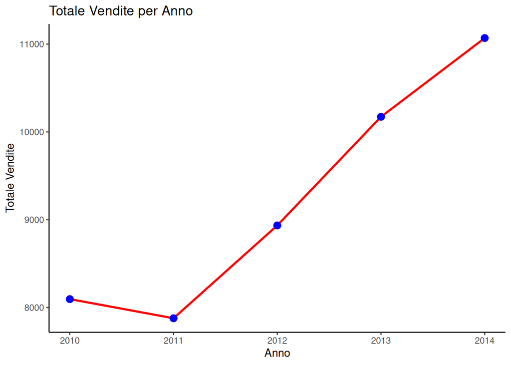

```r
#Line charts
vendite_per_anni <- dati %>%
  group_by(year) %>%
  summarize(totale_vendite = sum(sales, na.rm = TRUE)) %>%
  ungroup()

ggplot(data = vendite_per_anni)+
  geom_line(aes(x=year, y=totale_vendite), col="red", lwd=1)+
  geom_point(aes(x=year, y=totale_vendite), col="blue", size=3)+
  labs(title = "Totale Vendite per Anno",
       x = "Anno",
       y = "Totale Vendite") +
  theme_classic()
```

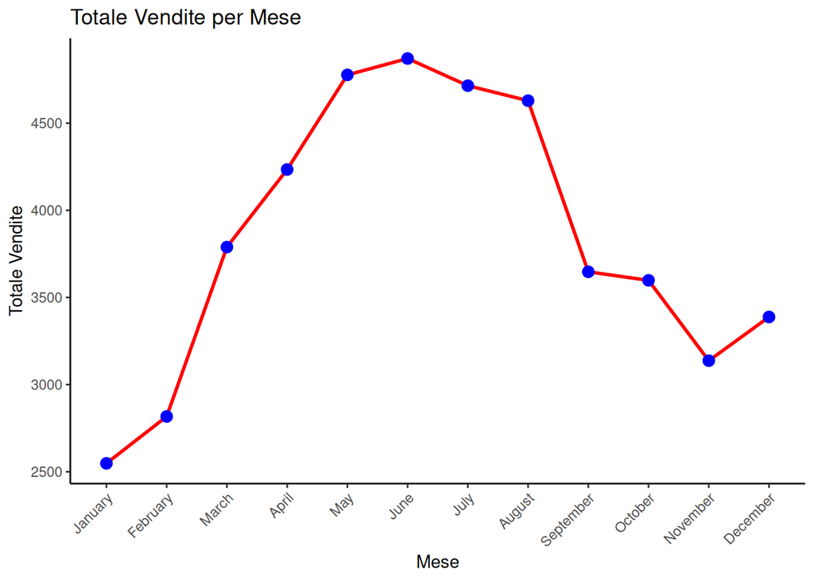

```r
ggplot(data = vendite_totali_mese)+
  geom_line(aes(x=month, y=totale_vendite, group=1), col="red", lwd=1)+
  geom_point(aes(x=month, y=totale_vendite, group=1), col="blue", size=3)+
  labs(title = "Totale Vendite per Mese",
       x = "Mese",
       y = "Totale Vendite") +
  theme_classic()+
  theme(axis.text.x = element_text(angle = 45, hjust = 1))
```

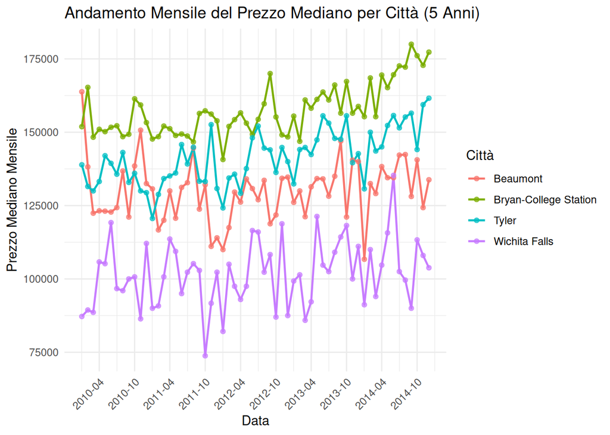

```r
library(lubridate)
dati$date <- make_date(dati$year, dati$month)

dati_agg_tempo <- dati %>%
  group_by(date, city) %>%
  summarise(
    avg_median_price = mean(median_price, na.rm = TRUE), # Media del prezzo mediano per mese/anno
    total_sales = sum(sales, na.rm = TRUE) # Totale vendite per mese/anno
    # Puoi aggiungere altre variabili qui, come 'mean_volume', ecc.
  ) %>%
  ungroup()

ggplot(dati_agg_tempo, aes(x = date, y = avg_median_price, color = city, group = city)) +
  geom_line(linewidth = 0.8) + # linewidth per lo spessore della linea
  geom_point(size = 1.5, alpha = 0.7) + # Punti per visualizzare i singoli mesi
  labs(
    title = "Andamento Mensile del Prezzo Mediano per Città (5 Anni)",
    x = "Data",
    y = "Prezzo Mediano Mensile",
    color = "Città" # Etichetta per la legenda del colore
  ) +
  theme_minimal() +
  scale_x_date(date_breaks = "6 months", date_labels = "%Y-%m") + # Formatta l'asse X per leggere meglio
  theme(axis.text.x = element_text(angle = 45, hjust = 1)) # Ruota le etichette dell'asse X
```

Questi tre grafici a linee invece non fanno altro che ribadire le tendenze di crescita annuale e la stagionalità mensile delle vendite che avevamo osservato nei grafici a barre, fornendo al contempo una visualizzazione più fluida e intuitiva di tali pattern.